# ExtraaLearn Project

## Context

The EdTech industry has been surging in the past decade immensely, and according to a forecast, the Online Education market would be worth $286.62bn by 2023 with a compound annual growth rate (CAGR) of 10.26% from 2018 to 2023. The modern era of online education has enforced a lot in its growth and expansion beyond any limit. Due to having many dominant features like ease of information sharing, personalized learning experience, transparency of assessment, etc, it is now preferable to traditional education.

In the present scenario due to the Covid-19, the online education sector has witnessed rapid growth and is attracting a lot of new customers. Due to this rapid growth, many new companies have emerged in this industry. With the availability and ease of use of digital marketing resources, companies can reach out to a wider audience with their offerings. The customers who show interest in these offerings are termed as leads. There are various sources of obtaining leads for Edtech companies, like

- The customer interacts with the marketing front on social media or other online platforms.
- The customer browses the website/app and downloads the brochure
- The customer connects through emails for more information.

The company then nurtures these leads and tries to convert them to paid customers. For this, the representative from the organization connects with the lead on call or through email to share further details.

## Objective

ExtraaLearn is an initial stage startup that offers programs on cutting-edge technologies to students and professionals to help them upskill/reskill. With a large number of leads being generated on a regular basis, one of the issues faced by ExtraaLearn is to identify which of the leads are more likely to convert so that they can allocate resources accordingly. You, as a data scientist at ExtraaLearn, have been provided the leads data to:

- Analyze and build an ML model to help identify which leads are more likely to convert to paid customers,
- Find the factors driving the lead conversion process
- Create a profile of the leads which are likely to convert

## Data Description

The data contains the different attributes of leads and their interaction details with ExtraaLearn. The detailed data dictionary is given below.

**Data Dictionary**

- ID: ID of the lead
- age: Age of the lead
- current_occupation: Current occupation of the lead. Values include 'Professional','Unemployed',and 'Student'
- first_interaction: How did the lead first interacted with ExtraaLearn. Values include 'Website', 'Mobile App'
- profile_completed: What percentage of profile has been filled by the lead on the website/mobile app. Values include Low - (0-50%), Medium - (50-75%), High (75-100%)
- website_visits: How many times has a lead visited the website
- time_spent_on_website: Total time spent on the website
- page_views_per_visit: Average number of pages on the website viewed during the visits.
- last_activity: Last interaction between the lead and ExtraaLearn.
  - Email Activity: Seeking for details about program through email, Representative shared information with lead like brochure of program , etc
  - Phone Activity: Had a Phone Conversation with representative, Had conversation over SMS with representative, etc
  - Website Activity: Interacted on live chat with representative, Updated profile on website, etc
- print_media_type1: Flag indicating whether the lead had seen the ad of ExtraaLearn in the Newspaper.
- print_media_type2: Flag indicating whether the lead had seen the ad of ExtraaLearn in the Magazine.
- digital_media: Flag indicating whether the lead had seen the ad of ExtraaLearn on the digital platforms.
- educational_channels: Flag indicating whether the lead had heard about ExtraaLearn in the education channels like online forums, discussion threads, educational websites, etc.
- referral: Flag indicating whether the lead had heard about ExtraaLearn through reference.
- status: Flag indicating whether the lead was converted to a paid customer or not.

## Importing necessary libraries and data

```python
import pandas as pd
import numpy as np


# data visualization and EDA
import matplotlib.pyplot as plt
import seaborn as sns

# model building and evaluation
from sklearn.model_selection import train_test_split
import statsmodels.stats.api as sms
from statsmodels.stats.outliers_influence import variance_inflation_factor
import statsmodels.api as sm
from statsmodels.tools.tools import add_constant
from sklearn.linear_model import LogisticRegression
from sklearn.tree import DecisionTreeClassifier
from sklearn import tree
from sklearn.ensemble import RandomForestClassifier
from sklearn.model_selection import GridSearchCV
import sklearn.metrics as metrics
from sklearn.metrics import (
    f1_score,
    accuracy_score,
    recall_score,
    precision_score,
    confusion_matrix,
    classification_report,
    roc_auc_score,
    precision_recall_curve,
    roc_curve,
    make_scorer,
)
```

## Data Overview

- Observations
- Sanity checks

```python
df = pd.read_csv("C:/Users/adars/OneDrive/Desktop/Data Science GL/Week 5 -  Classification and Hypothesis Testing/Project/ExtraaLearn.csv")
```

```python
df.head()
```

|  | ID | age | current_occupation | first_interaction | profile_completed | website_visits | time_spent_on_website | page_views_per_visit | last_activity | print_media_type1 | print_media_type2 | digital_media | educational_channels | referral | status |
| --- | --- | --- | --- | --- | --- | --- | --- | --- | --- | --- | --- | --- | --- | --- | --- |
| 0 | EXT001 | 57 | Unemployed | Website | High | 7 | 1639 | 1.861 | Website Activity | Yes | No | Yes | No | No | 1 |
| 1 | EXT002 | 56 | Professional | Mobile App | Medium | 2 | 83 | 0.320 | Website Activity | No | No | No | Yes | No | 0 |
| 2 | EXT003 | 52 | Professional | Website | Medium | 3 | 330 | 0.074 | Website Activity | No | No | Yes | No | No | 0 |
| 3 | EXT004 | 53 | Unemployed | Website | High | 4 | 464 | 2.057 | Website Activity | No | No | No | No | No | 1 |
| 4 | EXT005 | 23 | Student | Website | High | 4 | 600 | 16.914 | Email Activity | No | No | No | No | No | 0 |

```python
df.tail()
```

[output not shown]

## Exploratory Data Analysis (EDA)

- EDA is an important part of any project involving data.
- It is important to investigate and understand the data better before building a model with it.
- A few questions have been mentioned below which will help you approach the analysis in the right manner and generate insights from the data.
- A thorough analysis of the data, in addition to the questions mentioned below, should be done.

```python
df.shape
```

```
(4612, 15)
```

```python
df.dtypes
```

```
ID                        object
age                        int64
current_occupation        object
first_interaction         object
profile_completed         object
website_visits             int64
time_spent_on_website      int64
page_views_per_visit     float64
last_activity             object
print_media_type1         object
print_media_type2         object
digital_media             object
educational_channels      object
referral                  object
status                     int64
dtype: object
```

```python
#check duplicates
print(df.duplicated().sum())
```

```
0
```

```python
#check for missing values
df.isnull()

print(df.isnull().sum())
```

```
ID                       0
age                      0
current_occupation       0
first_interaction        0
profile_completed        0
website_visits           0
time_spent_on_website    0
page_views_per_visit     0
last_activity            0
print_media_type1        0
print_media_type2        0
digital_media            0
educational_channels     0
referral                 0
status                   0
dtype: int64
```

```python
df.describe()
```

|  | age | website_visits | time_spent_on_website | page_views_per_visit | status |
| --- | --- | --- | --- | --- | --- |
| count | 4612.000000 | 4612.000000 | 4612.000000 | 4612.000000 | 4612.000000 |
| mean | 46.201214 | 3.566782 | 724.011275 | 3.026126 | 0.298569 |
| std | 13.161454 | 2.829134 | 743.828683 | 1.968125 | 0.457680 |
| min | 18.000000 | 0.000000 | 0.000000 | 0.000000 | 0.000000 |
| 25% | 36.000000 | 2.000000 | 148.750000 | 2.077750 | 0.000000 |
| 50% | 51.000000 | 3.000000 | 376.000000 | 2.792000 | 0.000000 |
| 75% | 57.000000 | 5.000000 | 1336.750000 | 3.756250 | 1.000000 |
| max | 63.000000 | 30.000000 | 2537.000000 | 18.434000 | 1.000000 |

## Data Preprocessing

- Missing value treatment (if needed)
- Feature engineering (if needed)
- Outlier detection and treatment (if needed)
- Preparing data for modeling
- Any other preprocessing steps (if needed)

```python
df.drop(["ID"], axis = 1, inplace = True)
```

## EDA

- It is a good idea to explore the data once again after manipulating it.

```python
df.head()
```

|  | age | current_occupation | first_interaction | profile_completed | website_visits | time_spent_on_website | page_views_per_visit | last_activity | print_media_type1 | print_media_type2 | digital_media | educational_channels | referral | status |
| --- | --- | --- | --- | --- | --- | --- | --- | --- | --- | --- | --- | --- | --- | --- |
| 0 | 57 | Unemployed | Website | High | 7 | 1639 | 1.861 | Website Activity | Yes | No | Yes | No | No | 1 |
| 1 | 56 | Professional | Mobile App | Medium | 2 | 83 | 0.320 | Website Activity | No | No | No | Yes | No | 0 |
| 2 | 52 | Professional | Website | Medium | 3 | 330 | 0.074 | Website Activity | No | No | Yes | No | No | 0 |
| 3 | 53 | Unemployed | Website | High | 4 | 464 | 2.057 | Website Activity | No | No | No | No | No | 1 |
| 4 | 23 | Student | Website | High | 4 | 600 | 16.914 | Email Activity | No | No | No | No | No | 0 |

**Questions**

1. Leads will have different expectations from the outcome of the course and the current occupation may play a key role in getting them to participate in the program. Find out how current occupation affects lead status.
2. The company's first impression on the customer must have an impact. Do the first channels of interaction have an impact on the lead status?
3. The company uses multiple modes to interact with prospects. Which way of interaction works best?
4. The company gets leads from various channels such as print media, digital media, referrals, etc. Which of these channels have the highest lead conversion rate?
5. People browsing the website or mobile application are generally required to create a profile by sharing their personal data before they can access additional information.Does having more details about a prospect increase the chances of conversion?

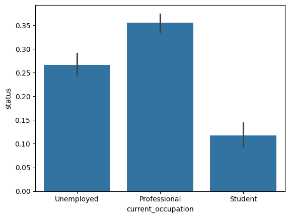

```python
#Leads will have different expectations from the outcome of the course and the current occupation may play a key role in getting them to participate
#Find out how current occupation affects lead status.


sns.barplot(x='current_occupation', y='status', data= df)

plt.show()
```

#### Those with a professional occupation were actually the most successfully converted leads

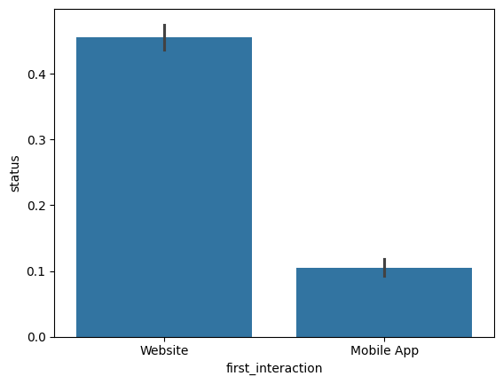

```python
#Do the first channels of interaction have an impact on the lead status
sns.barplot(x='first_interaction', y='status', data= df)

plt.show()
```

#### First interaction through the website resulted in significantly more lead conversions

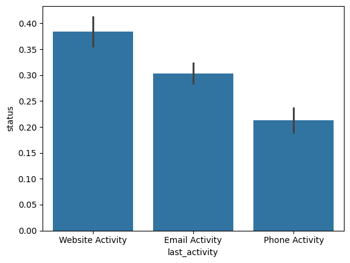

```python
#The company uses multiple modes to interact with prospects. Which way of interaction works best
sns.barplot(x='last_activity', y='status', data= df)

plt.show()
```

### interacting through the website lead to most conversions

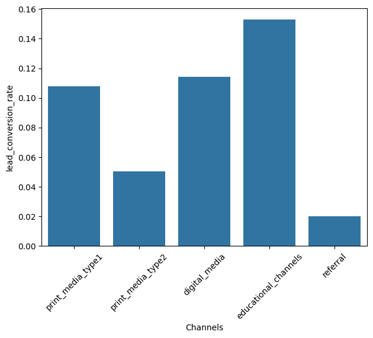

```python
#The company gets leads from various channels such as print media, digital media, referrals, etc.
#Which of these channels have the highest lead conversion rate?
#

channels = ['print_media_type1', 'print_media_type2', 'digital_media',
        'educational_channels', 'referral']

#Calculate lead conversion rate
lcr = df[channels].apply(lambda x: (x == 'Yes').mean())

# Convert to DataFrame for plotting
lcr = lcr.reset_index()
lcr.columns = ['Channels', 'lead_conversion_rate']

# Plot
sns.barplot(x='Channels', y='lead_conversion_rate', data=lcr)
plt.tight_layout()
plt.xticks(rotation=45)
plt.show()
```

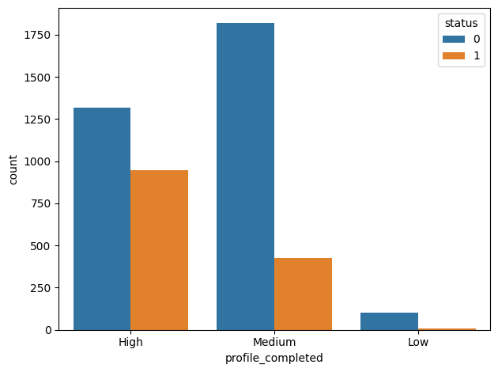

```python
#Does having more details about a prospect increase the chances of conversion?

sns.countplot(x = 'profile_completed', hue = 'status', data = df)
plt.tight_layout()
plt.show()
```

### a high profile completion shows significantly better conversion rates

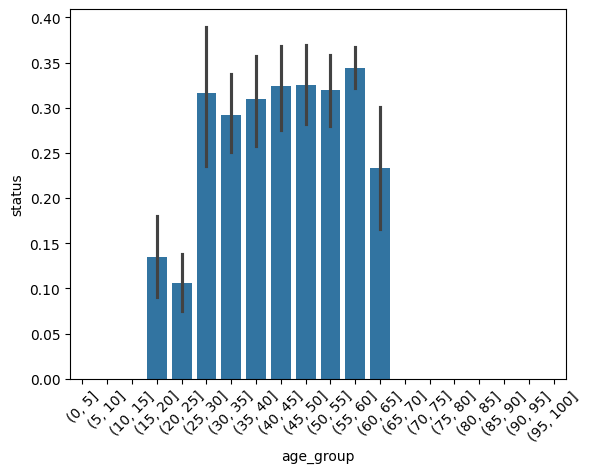

```python
#Effect of Age on lead conversion rate?

df['age_group'] = pd.cut(df['age'], bins=range(0, 101, 5))


sns.barplot(x='age_group', y='status', data=df)
plt.xticks(rotation=45)

plt.show()
```

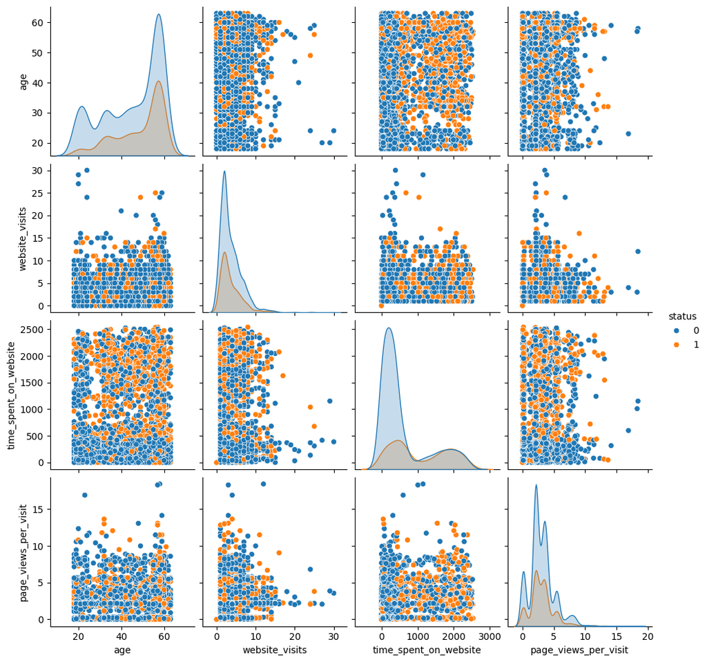

```python
#bivariate analysis
sns.pairplot(data = df, hue ='status')
```

## Building a Decision Tree model

```python
# Data Preparation
data = pd.get_dummies(df)
```

```python
X = data.drop('status', axis=1)
y = data['status']
```

```python
X_train, X_test, y_train, y_test = train_test_split(X, y, test_size=0.3, random_state=42)
```

```python
#from sklearn.tree import DecisionTreeClassifier
dt_model.fit(X_train, y_train)

dt_model = DecisionTreeClassifier(max_depth=5, min_samples_split=10, random_state=42)
dt_model.fit(X_train, y_train)
```

```
DecisionTreeClassifier(max_depth=5, min_samples_split=10, random_state=42)
```

## Do we need to prune the tree?

```python
#creating function to evaluate model

def metrics_score(actual, predicted):
    print(classification_report(actual, predicted))

    cm = confusion_matrix(actual, predicted)
    plt.figure(figsize=(8,5))

    sns.heatmap(cm, annot=True,  fmt='.2f')
    plt.ylabel('Actual')
    plt.xlabel('Predicted')
    plt.show()
```

```
              precision    recall  f1-score   support

           0       0.88      0.94      0.91      2258
           1       0.83      0.71      0.77       970

    accuracy                           0.87      3228
   macro avg       0.86      0.83      0.84      3228
weighted avg       0.87      0.87      0.87      3228
```

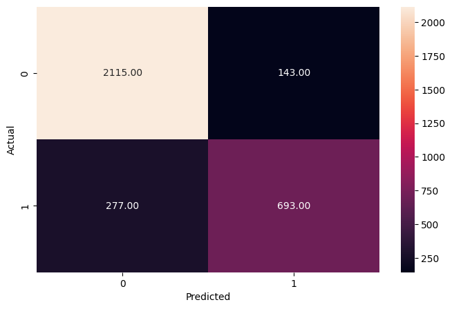

```python
#evaluating the model first on training data
y_pred_train1 = dt_model.predict(X_train)

metrics_score(y_train, y_pred_train1)
```

```
              precision    recall  f1-score   support

           0       0.88      0.93      0.91       977
           1       0.80      0.71      0.75       407

    accuracy                           0.86      1384
   macro avg       0.84      0.82      0.83      1384
weighted avg       0.86      0.86      0.86      1384
```

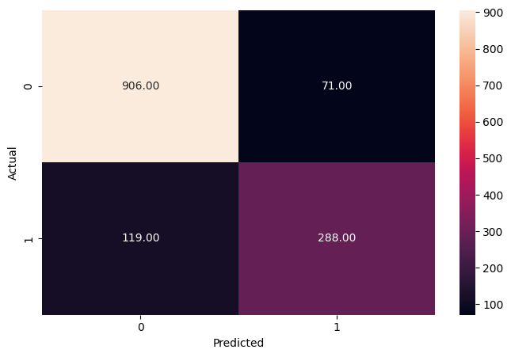

```python
#now on test data
y_pred_test1 = dt_model.predict(X_test)

metrics_score(y_test, y_pred_test1)
```

#### Our buffer against overfitting (Which decision trees are prone to) seems to have worked quite nicely. By adjusting max depth to have an upper limit and minimum samples split to have a floor we see that the training data shows high but not perfect recall (0.71) and this matches the test data (0.71). This is what we are looking for and the model doesn't need further pruning.

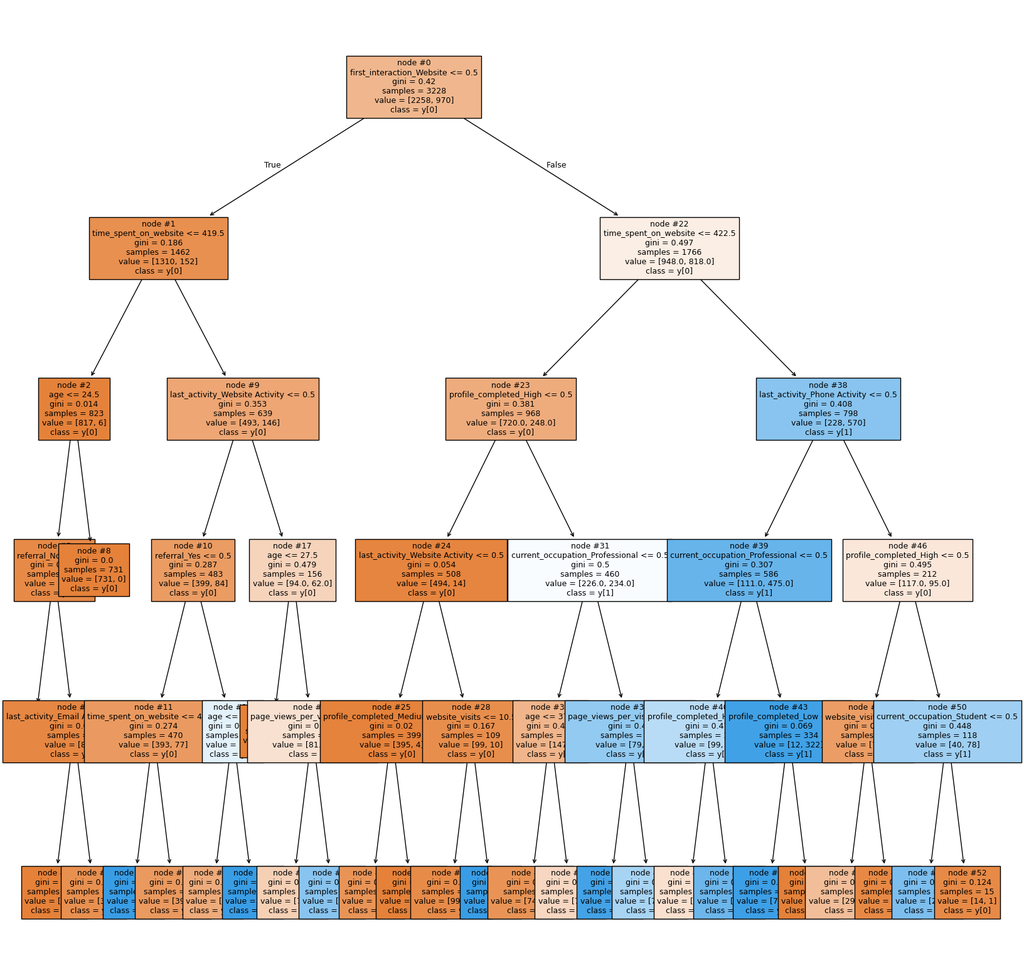

```python
#visualizing the tree

plt.figure(figsize = (20, 20))
tree.plot_tree(dt_model, feature_names = list(X.columns), filled = True, fontsize = 9, node_ids = True, class_names = True)
plt.show()
```

## Building a Random Forest model

```python
rf_model = RandomForestClassifier(n_estimators=100, random_state=42)

rf_model.fit(X_train, y_train)
```

```
RandomForestClassifier(random_state=42)
```

## Do we need to prune the tree?

```
              precision    recall  f1-score   support

           0       1.00      1.00      1.00      2258
           1       1.00      1.00      1.00       970

    accuracy                           1.00      3228
   macro avg       1.00      1.00      1.00      3228
weighted avg       1.00      1.00      1.00      3228
```

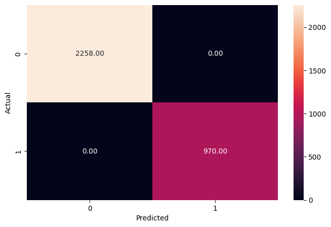

```python
#evaluating the random forest model on training data
y_pred_train2 = rf_model.predict(X_train)

metrics_score(y_train, y_pred_train2)
```

#### We are seeing perfect 1.00 recall and precision on the training data which is an indicator of overfitting, we need to do some tuning to increase the model's performance.

```
              precision    recall  f1-score   support

           0       0.88      0.92      0.90       977
           1       0.79      0.69      0.73       407

    accuracy                           0.85      1384
   macro avg       0.83      0.80      0.82      1384
weighted avg       0.85      0.85      0.85      1384
```

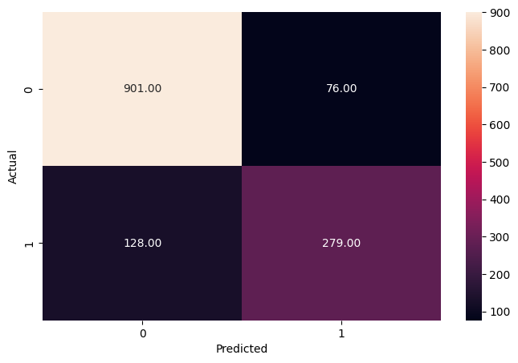

```python
#on test data
y_pred_test2 = rf_model.predict(X_test)

metrics_score(y_test, y_pred_test2)
```

#### Recall is low (0.69) and is lower than precision and f1 score. This is not ideal as the accuracy of the negative test matters most to us.

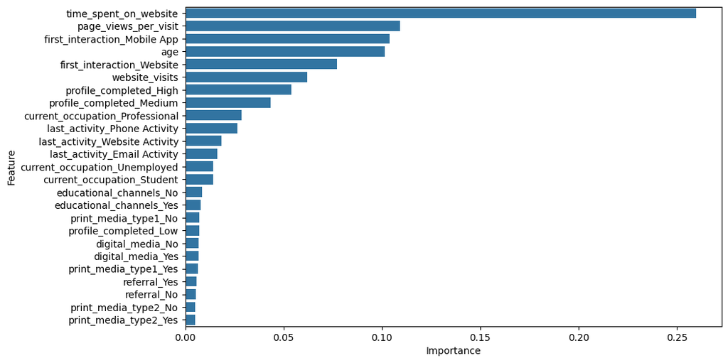

```python
#featureimportances

importances = rf_model.feature_importances_
feature_names = X.columns

# Create DataFrame
feature_imp = pd.DataFrame({'Feature': feature_names,'Importance': importances})

# Sort values
feature_imp = feature_imp.sort_values(by='Importance', ascending=False)

# Plot
plt.figure(figsize=(10, 6))
sns.barplot(x='Importance', y='Feature', data=feature_imp)

plt.show()
```

```python
#Using GridsearchCV to tune the model


parameters = {'n_estimators': [100, 200], 'max_depth': [None, 5, 10], 'min_samples_split': [2, 5, 10], 'min_samples_leaf': [1, 2, 4]}


grid_search = GridSearchCV(estimator=rf_model, param_grid=parameters, cv=5, scoring='recall', verbose=1)

grid_search.fit(X_train, y_train)


rf_model_tuned = grid_search.best_estimator_
```

```
Fitting 5 folds for each of 54 candidates, totalling 270 fits
```

```python
rf_model_tuned.fit(X_train, y_train)
```

```
RandomForestClassifier(max_depth=10, random_state=42)
```

```
              precision    recall  f1-score   support

           0       0.94      0.95      0.95      2258
           1       0.89      0.85      0.87       970

    accuracy                           0.92      3228
   macro avg       0.91      0.90      0.91      3228
weighted avg       0.92      0.92      0.92      3228
```

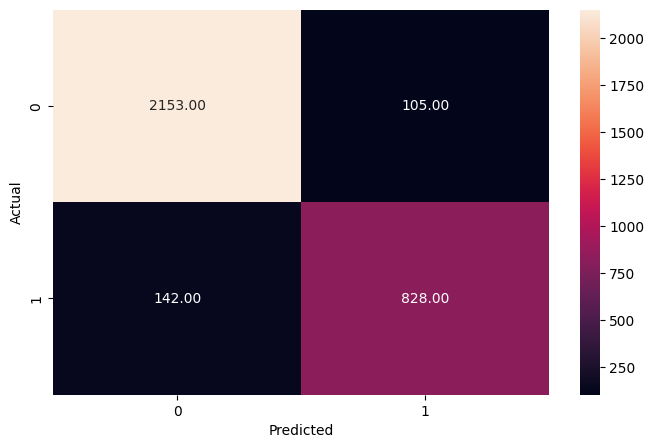

```python
#evaluating on the training data
y_pred_train3 = rf_model_tuned.predict(X_train)

metrics_score(y_train, y_pred_train3)
```

```
              precision    recall  f1-score   support

           0       0.88      0.93      0.91       977
           1       0.81      0.70      0.75       407

    accuracy                           0.86      1384
   macro avg       0.85      0.82      0.83      1384
weighted avg       0.86      0.86      0.86      1384
```

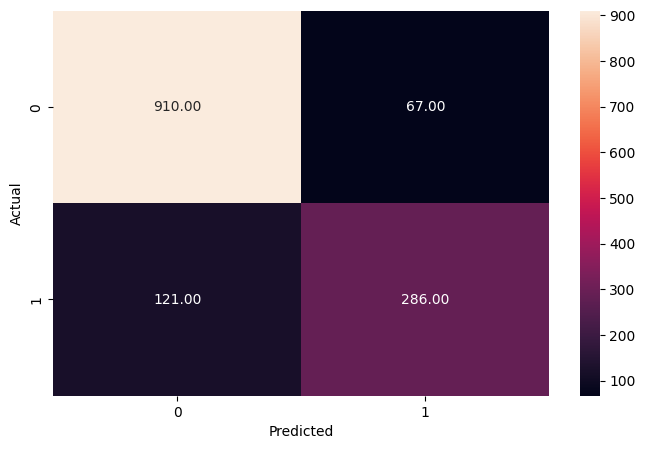

```python
#evaluating on the test data

y_pred_test3 = rf_model_tuned.predict(X_test)

metrics_score(y_test, y_pred_test3)
```

#### We see marginal improvement but not as much as hoped for, maybe in the future should understand what other parameters could be tuned for greater effectiveness.

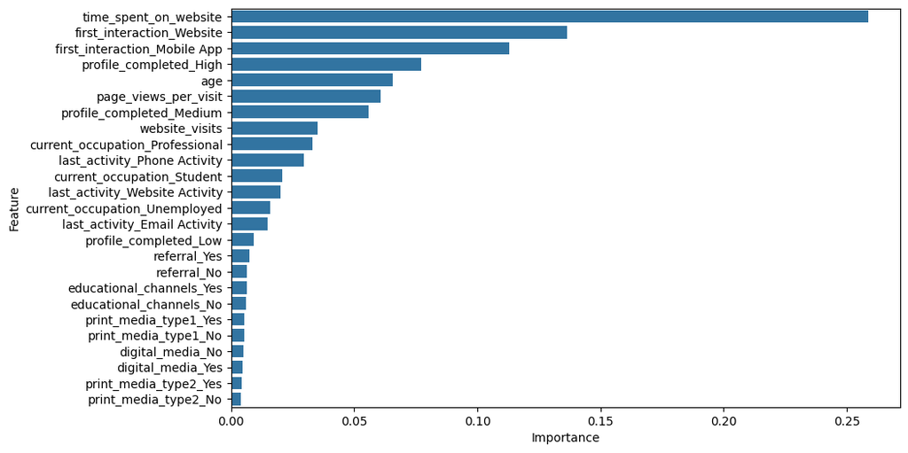

```python
importances = rf_model_tuned.feature_importances_
feature_names = X.columns

# Create DataFrame
feature_imp_tuned = pd.DataFrame({'Feature': feature_names,'Importance': importances})

# Sort values
feature_imp_tuned = feature_imp_tuned.sort_values(by='Importance', ascending=False)

# Plot
plt.figure(figsize=(10, 6))
sns.barplot(x='Importance', y='Feature', data=feature_imp_tuned)

plt.show()
```